# R Notebook

# Reminder on descriptive statistics

```r
data(iris)
X = iris$Sepal.Length
```

Let’s look at the histogram of this variable:

```r
hist(X)
```

As I said, it is possible to tell a very different stoty with the histogram if we use a different number of breaks:

```r
hist(X,breaks = 100)
```

The selection of the number of slices can be performed automatically in R with a least 3 different algorithms!

It is also interesting to combine the histogram with an estimation of the pdf function made by `density`:

```r
hist(X,freq = FALSE)
lines(density(X),col=2,lwd=2)
```

Let’s now use boxplots:

```r
boxplot(X)
```

and to relate the boxplot with the histogram:

```r
par(mfrow=c(2,1))
hist(X,freq = FALSE)
lines(density(X),col=2,lwd=2)
boxplot(X,horizontal = TRUE)
```

Regarding multivariate data, it is possible for the iris data to plot several boxplots side by side because the 4 variables are all expressed on the same unit (cm).

```r
boxplot(iris[,-5])
```

The alternative would be:

```r
par(mfrow=c(2,2))
for (j in 1:4) boxplot(iris[,j],main=paste('variable',j))
```

About scatterplot / pair plot now:

```r
plot(iris[,-5])
```

It is possible to add to this plot an additional categorical variable (here the species):

```r
plot(iris[,-5],col=as.numeric(iris$Species))
```

of course, it is possible to have a classical scatter plot when looking only at 2 variables:

```r
plot(iris$Sepal.Length,iris$Petal.Length,col=as.numeric(iris$Species))
```

## Multivariate numerical indicators

Mean:

```r
data(iris)
mu = colMeans(iris[,-5])
mu
```

Covariance and correlation matrices:

```r
S = cov(iris[,-5])
S

C = cor(iris[,-5])
C
```

# The learning process in supervised classification

## LDA and logistic regression

Let’s first apply LDA on the iris data:

```r
data(iris)
X = iris[,-5]
Y = as.numeric(iris$Species)

library(MASS)
system.time(f <- lda(X,Y))
```

After the learning, it is possible to examine the output:

```r
f
```

Afterward, if we would like to classify a new observation, we have to call the `predict` function:

```r
xstar = c(6, 2.9, 5, 3)
ystar = predict(f,xstar)
ystar
```

> Exercise: evaluate with the minimal setup or V-fold cross-validation the error rate that we can expect for LDA on this classification problem.

```r
n = nrow(X)
learn = sample(1:n,2/3*n)
f <- lda(X[learn,],Y[learn])
ystar = predict(f,X[-learn,])

# Computer the classification error
err = sum(Y[-learn] != ystar$class) / length(ystar$class)
err
```

A better version with resampling:

```r
n = nrow(X)
err = c()
for (i in 1:10){
  learn = sample(1:n,2/3*n)
  f <- lda(X[learn,],Y[learn])
  ystar = predict(f,X[-learn,])

  # Computer the classification error
  err[i] = sum(Y[-learn] != ystar$class) / length(ystar$class)
}
boxplot(err)
```

## Classification with KNN

A basic call to KNN is as follows:

```r
data(iris)
X = iris[,-5]
Y = as.numeric(iris$Species)

library(class)
?knn

xstar = c(6, 2.9, 5, 3)
ystar = knn(X,xstar,Y,k = 5)
ystar
```

> Exercise: evaluate with a V-fold cross-validation the performance of KNN (with K=5) on the iris data set.

```r
library(MASS)
V = 25
n = nrow(X)
fold = rep(1:V,n/V)
err.knn5 = err.lda = rep(NA,V)
for (v in 1:V){
  learn = which(fold != v)
  test = which(fold == v)

  # KNN
  ystar = knn(X[learn,],X[test,],Y[learn],k = 5)
  err.knn5[v] = sum(ystar != Y[test]) / length(ystar)

  # LDA
  f <- lda(X[learn,],Y[learn])
  ystar = predict(f,X[test,])$class
  err.lda[v] = sum(ystar != Y[test]) / length(ystar)
}
cat(paste('> KNN5:',mean(err.knn5),'+/-',sd(err.knn5),'\n'))
cat(paste('> LDA:',mean(err.lda),'+/-',sd(err.lda),'\n'))
```

> Exercise: use V-fold cross-validation to find the appropriate value for K in KNN on the iris classification problem.

```r
library(MASS)
V = 25 ; K = 30
n = nrow(X)
fold = rep(1:V,n/V)
err.knn = matrix(NA,K,V)

for (v in 1:V){
  learn = which(fold != v)
  test = which(fold == v)
  for (k in 1:K){
    ystar = knn(X[learn,],X[test,],Y[learn],k)
    err.knn[k,v] = sum(ystar != Y[test]) / length(ystar)
  }
}
plot(rowMeans(err.knn),type='b')
```

> WARNING: To compare the performance of KNN in general with LDA, we should use double CV for both picking the best K and evaluating the performance

```r
library(MASS)
V = 25
n = nrow(X)
fold = rep(1:V,n/V)
err.knn = err.lda = rep(NA,V)
for (v in 1:V){
  learn = which(fold != v)
  test = which(fold == v)

  # KNN (with an internal CV for picking K)
  X2 = X[learn,]; Y2 = Y[learn]
  K = 30; n2 = nrow(X2)
  fold2 = rep(1:V,n2/V)
  err.knn2 = matrix(NA,K,V)

  for (v2 in 1:V){ # Start of the internal CV
    learn2 = which(fold2 != v2)
    test2 = which(fold2 == v2)
    for (k in 1:K){
      ystar = knn(X2[learn2,],X2[test2,],Y2[learn2],k)
      err.knn2[k,v2] = sum(ystar != Y2[test2]) / length(ystar)
    }
  }
  Kstar = which.min(rowMeans(err.knn2)) # Choice of K* for this fold

  # Evaluation of the error for this fold
  ystar = knn(X[learn,],X[test,],Y[learn],k = Kstar)
  err.knn[v] = sum(ystar != Y[test]) / length(ystar)

  # LDA
  f <- lda(X[learn,],Y[learn])
  ystar = predict(f,X[test,])$class
  err.lda[v] = sum(ystar != Y[test]) / length(ystar)
}
cat(paste('> KNN:',mean(err.knn),'+/-',sd(err.knn),'\n'))
cat(paste('> LDA:',mean(err.lda),'+/-',sd(err.lda),'\n'))
```

## Classification with SVM

The SVM function is provided in R within different packages. In particular, the package ‘e1071’ provides a nice implementation of SVM.

```r
#install.packages('e1071')
library(e1071)
```

A basic use of SVM on the iris data would be:

```r
data(iris)
X = iris[,-5]
Y = as.numeric(iris$Species)

xstar = c(6, 2.9, 5, 3)
f.svm = svm(X,Y,kernel = 'radial',gamma = 1,type = "C-classification")
ystar = predict(f.svm,matrix(xstar,nrow=1))
ystar
```

> Exercise: use cross-validation to find the best value for gamma within the RBF kernel for this classification task.

```r
V = 25 ; GAMMA = seq(0.01,1,by=0.01)
n = nrow(X)
fold = rep(1:V,n/V)
err.svm = matrix(NA,length(GAMMA),V)

for (v in 1:V){
  learn = which(fold != v)
  test = which(fold == v)
  for (j in 1:length(GAMMA)){
    gamma = GAMMA[j]
    f.svm = svm(X[learn,],Y[learn],kernel='radial',gamma=gamma,
                type= "C-classification")
    ystar = predict(f.svm,X[test,])
    err.svm[j,v] = sum(ystar != Y[test]) / length(ystar)
  }
}
plot(GAMMA,rowMeans(err.svm),type='b')
title(main=paste('Best gamma value:',GAMMA[which.min(rowMeans(err.svm))],'\n'))
```

> Exercise: apply double cross-validation to find the best kernel (among linear, radial and polynomial) for SVM and compare to KNN and LDA (with 10-fold CV)

```r
V = 10; n = nrow(X)
fold = rep(1:V,n/V)
err.knn = err.lda = rep(NA,V)
err.svm1 = err.svm2 = err.svm3 = rep(NA,V)
for (v in 1:V){
  learn = which(fold != v)
  test = which(fold == v)

  # KNN (with an internal CV for picking K)
  X2 = X[learn,]; Y2 = Y[learn]
  K = 15; n2 = nrow(X2)
  fold2 = rep(1:V,n2/V)
  err.knn2 = matrix(NA,K,V)

  for (v2 in 1:V){ # Start of the internal CV
    learn2 = which(fold2 != v2)
    test2 = which(fold2 == v2)
    for (k in 1:K){
      ystar = knn(X2[learn2,],X2[test2,],Y2[learn2],k)
      err.knn2[k,v2] = sum(ystar != Y2[test2]) / length(ystar)
    }
  }
  Kstar = which.min(rowMeans(err.knn2)) # Choice of K* for this fold

  # Evaluation of the error for this fold
  ystar = knn(X[learn,],X[test,],Y[learn],k = Kstar)
  err.knn[v] = sum(ystar != Y[test]) / length(ystar)

  # LDA #############
  f <- lda(X[learn,],Y[learn])
  ystar = predict(f,X[test,])$class
  err.lda[v] = sum(ystar != Y[test]) / length(ystar)

  # SVM linear #############
  f.svm = svm(X[learn,],Y[learn],kernel = 'linear',type = "C-classification")
  ystar = predict(f.svm,X[test,])
  err.svm1[v] = sum(ystar != Y[test]) / length(ystar)

  # SVM radial #############
  X2 = X[learn,]; Y2 = Y[learn]; n2 = nrow(X2)
  GAMMA = seq(0.01,1,by=0.01); int.svm2 = matrix(NA,length(GAMMA),V)
  fold2 = rep(1:V,n2/V)

  for (v2 in 1:V){ # Start of the internal CV
    learn2 = which(fold2 != v2)
    test2 = which(fold2 == v2)
    for (j in 1:length(GAMMA)){
      gamma = GAMMA[j]
      f.svm = svm(X2[learn2,],Y2[learn2],kernel='radial',gamma=gamma,
                type= "C-classification")
      ystar2 = predict(f.svm,X2[test2,])
      int.svm2[j,v2] = sum(ystar2 != Y2[test2]) / length(ystar2)
    }
  }
  GammaStar = GAMMA[which.min(rowMeans(int.svm2))]

  # Evaluation of the error for this fold
  f.svm = svm(X[learn,],Y[learn],kernel = 'radial',gamma = GammaStar,
              type = "C-classification")
  ystar = predict(f.svm,X[test,])
  err.svm2[v] = sum(ystar != Y[test]) / length(ystar)
}
cat(paste('> KNN:',mean(err.knn),'+/-',sd(err.knn),'\n'))
cat(paste('> LDA:',mean(err.lda),'+/-',sd(err.lda),'\n'))
cat(paste('> SVM linear:',mean(err.svm1),'+/-',sd(err.svm1),'\n'))
cat(paste('> SVM radial:',mean(err.svm2),'+/-',sd(err.svm2),'\n'))
```

# Unsupervised learning

## Dimension reduction with PCA

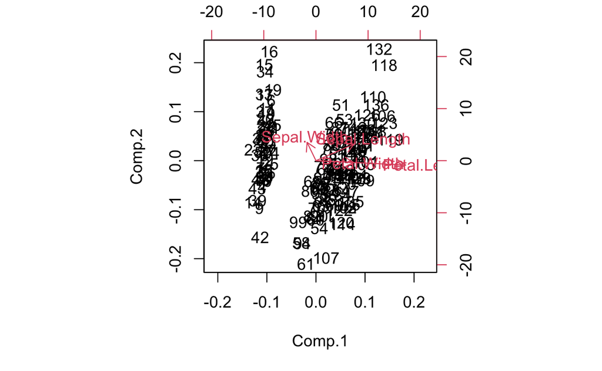

```r
data(iris)
X = iris[,-5]
cls = as.numeric(iris$Species)

# The usual manner to do PCA in R
pca = princomp(X)
biplot(pca)
```

We can compare the observations in the orignal space with their projection on the new variables:

```r
Y = predict(pca)[,1:2]

# coordinates of the 1st individual in the original space (X)
X[1,]
```

|  | Sepal.Length | Sepal.Width | Petal.Length | Petal.Width |
| --- | --- | --- | --- | --- |
| 1 | 5.1 | 3.5 | 1.4 | 0.2 |

```r
# coordinates of the 1st individual in the projection space (Y = X * U)
Y[1,]
```

```
    Comp.1     Comp.2
-2.6841256  0.3193972
```

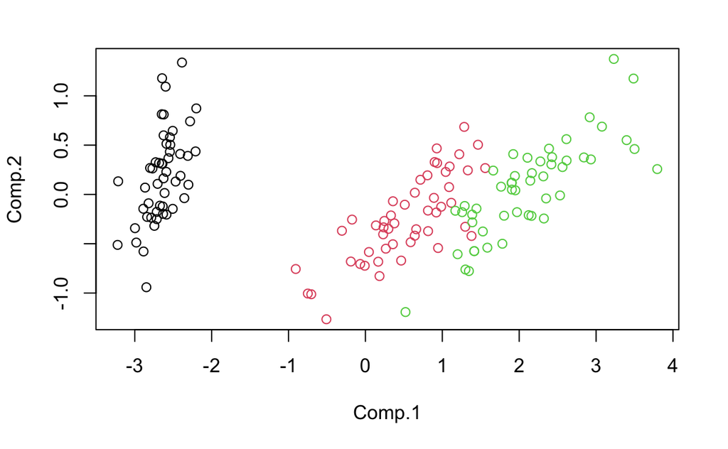

```r
plot(Y,col=cls)
```

## Another example of PCA with the decatholon data

Let’s first load the data (from internet):

```r
decathlon = read.table("http://math.agrocampus-ouest.fr/infoglueDeliverLive/digitalAssets/108286_decathlon.csv",header=TRUE,sep=';')

dim(X)
```

```
[1] 150   4
```

```r
X =  decathlon[,2:11]
rownames(X) = decathlon$X
```

```r
# 500m has a strong correlation ← means very important
pca = princomp(X)
par(mfrow=c(1,2))
biplot(pca, col=c(0,2))

Y = predict(pca)[,1:2]
plot(Y, type='n')
```

[figure not shown]

```r
text(Y, labels=rownames(X))
```

```r
Y = predict(pca)[,1:2]

# coordinates of the 1st individual in the original space (X)
X[1,]
```

|  | X100m | Longueur | Poids | Hauteur | X400m | X110m.H | Disque | Perche | Javelot | X1500m |
| --- | --- | --- | --- | --- | --- | --- | --- | --- | --- | --- |
| Sebrle | 10.85 | 7.84 | 16.36 | 2.12 | 48.36 | 14.05 | 48.72 | 5 | 70.52 | 280.01 |

```r
# coordinates of the 1st individual in the projection space (Y = X * U)
Y[1,]
```

```
     Comp.1      Comp.2
 -0.2368017 -13.0809090
```

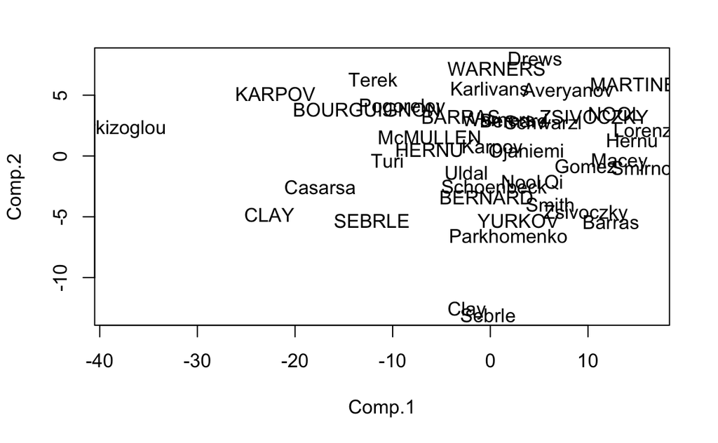

```r
plot(Y, type='n')
text(Y, labels=rownames(X))
```

```r
summary(pca)
```

```
Importance of components:
                           Comp.1    Comp.2    Comp.3      Comp.4      Comp.5       Comp.6
Standard deviation     11.6106540 4.7891085 3.1220607 1.056984087 0.589720672 0.3642552340
Proportion of Variance  0.7965959 0.1355296 0.0575980 0.006601788 0.002055026 0.0007840365
Cumulative Proportion   0.7965959 0.9321255 0.9897235 0.996325247 0.998380274 0.9991643100
                            Comp.7      Comp.8       Comp.9      Comp.10
Standard deviation     0.249171229 0.222227318 0.1582500495 7.006272e-02
Proportion of Variance 0.000366877 0.000291823 0.0001479832 2.900673e-05
Cumulative Proportion  0.999531187 0.999823010 0.9999709933 1.000000e+00
```

Here, two PCA components are enough to explain 93% of the variance The other rule is to look for a break in the eigenvalue script

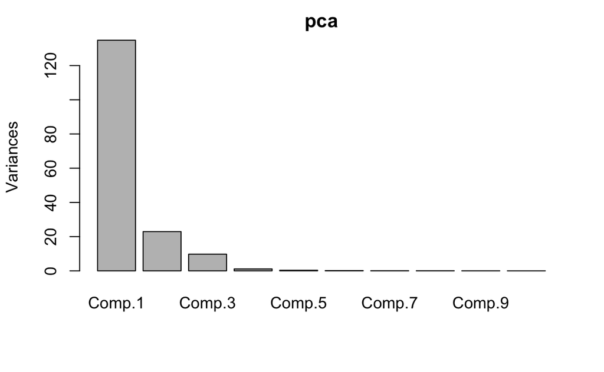

```r
screeplot(pca)
```

On this example, we perhaps would prefer $d=3$ Normalization: There is no firm theory to ensure that normalization works